# US Census Demographic Data

Data lovers

09 Nov 2021

### Chapter 1:Introduction.

Census is a very important matter, not just at the government level, but for individuals as well. The census population count decides how many congressional members each state will have for the following ten years, as well as how much federal funds localities will receive for roads, schools, housing, and social programs.

Poverty is a complicated issue. There are numerous elements to it, as well as numerous reasons. The most common definition of poverty focuses on financial hardship. This definition defines poverty rates for towns and countries based on income inequality and financially established poverty lines and quantifies poverty by the amount of money a person makes.

Poverty becomes relative in this way. In the United States, the poverty line for a family of four is little over $26,000 a year. That amount of money is more than 36 times what a family of four living in absolute poverty in a low-income country is forced to subsist on each year.

Many families in the world’s poorest countries must make do with less than $1.90 per day to cover their basic requirements. This sort of extreme poverty affects nearly 10% of the world’s population.

Understanding poverty solely in terms of economic disparity and calculating relative poverty thresholds makes it impossible to see poverty as anything other than unemployment, bad living conditions, and a low income. Poverty, on the other hand, is a much broader concept.

A fair definition of poverty must take into account the many various aspects of poverty, such as hunger and a lack of shelter, illiteracy and lack of access to education, being sick and unable to see a doctor, and fearing for one’s future.

By exploring this data and analyzing it we can come up with many insights, such as how the population varies across the states, which states that have the best transportation, how do income and poverty look like across US, employment/unemployment rates and so many questions that can be answered from these data.

Therefore, our aim in this project is to analyze the US census of 2015 to answer our interesting question:

What factors affect poverty in counties?

### Chapter 2:Description of the Data.

• Dataset that is used for our project is “US Census Demographic Data” taken from the common data source Kaggle (which is an online community of data scientists and machine learning practitioners.

Link: https://www.kaggle.com/muonneutrino/us-census-demographic-data?select=acs2015_county_data.csv

• Dataset contains information about (US Census 2015) American Community Survey 5-year estimates.

• Number of variables in the dataset is 37.

• Number of observations in the dataset is 3220.

• To perform Exploratory Data Analysis, we primarily focus on the following aspects(variables) from the dataset:

- TotalPop (Total population for county).
- Income. (Income in county).
- Poverty (Poverty rate in county).
- ChildPoverty. (Child poverty rate in county).
- Employed (Total employed for county).
- Unemployment. (Unemployment rate for county).
- Production. (Rate of this job sector in county).
- WorkAtHome. (Work-at-home rate in county).
- PublicWork. (Public work rate in county).
- SelfEmployed. (Self-employed rate in county).

**This is our dataset before performing any cleansing or dropping columns:**

```r
# importing the dataset as Adata, and making sure the data type for the variables are set properly for categorical variables.**

Adata1 <- data.frame(read.csv("acs2015_county_data.csv",header = TRUE))

str(Adata1)

#summary(Adata1)

#  we don't need to change any variables type, all of them set properly.
# There are a lot of variables , we may drop some of them, like :
#Hispanic, White,   Black,  Native, Asian   Pacific, IncomeErr, IncomePerCap,   IncomePerCapErr


# Dropping columns as agreed.

Adata <- data.frame (subset(Adata1, select = -c(Hispanic,White,Black, Native, Asian, Pacific,IncomeErr, IncomePerCap, IncomePerCapErr, Drive, Carpool, Transit, Walk, OtherTransp, MeanCommute)))

str(Adata)
#summary(Adata)
```

```
## 'data.frame':    3220 obs. of  37 variables:
##  $ CensusId       : int  1001 1003 1005 1007 1009 1011 1013 1015 1017 1019 ...
##  $ State          : chr  "Alabama" "Alabama" "Alabama" "Alabama" ...
##  $ County         : chr  "Autauga" "Baldwin" "Barbour" "Bibb" ...
##  $ TotalPop       : int  55221 195121 26932 22604 57710 10678 20354 116648 34079 26008 ...
##  $ Men            : int  26745 95314 14497 12073 28512 5660 9502 56274 16258 12975 ...
##  $ Women          : int  28476 99807 12435 10531 29198 5018 10852 60374 17821 13033 ...
##  $ Hispanic       : num  2.6 4.5 4.6 2.2 8.6 4.4 1.2 3.5 0.4 1.5 ...
##  $ White          : num  75.8 83.1 46.2 74.5 87.9 22.2 53.3 73 57.3 91.7 ...
##  $ Black          : num  18.5 9.5 46.7 21.4 1.5 70.7 43.8 20.3 40.3 4.8 ...
##  $ Native         : num  0.4 0.6 0.2 0.4 0.3 1.2 0.1 0.2 0.2 0.6 ...
##  $ Asian          : num  1 0.7 0.4 0.1 0.1 0.2 0.4 0.9 0.8 0.3 ...
##  $ Pacific        : num  0 0 0 0 0 0 0 0 0 0 ...
##  $ Citizen        : int  40725 147695 20714 17495 42345 8057 15581 88612 26462 20600 ...
##  $ Income         : num  51281 50254 32964 38678 45813 ...
```

[output cut: 46 more lines]

**And here is the summary of our dataset**

```r
summary(Adata)
```

```
##     CensusId        State              County             TotalPop
##  Min.   : 1001   Length:3220        Length:3220        Min.   :      85
##  1st Qu.:19032   Class :character   Class :character   1st Qu.:   11218
##  Median :30024   Mode  :character   Mode  :character   Median :   26035
##  Mean   :31394                                         Mean   :   99409
##  3rd Qu.:46106                                         3rd Qu.:   66430
##  Max.   :72153                                         Max.   :10038388
##
##       Men              Women            Citizen            Income
##  Min.   :     42   Min.   :     43   Min.   :     80   Min.   : 10499
##  1st Qu.:   5637   1st Qu.:   5572   1st Qu.:   8450   1st Qu.: 38192
##  Median :  12932   Median :  13057   Median :  19643   Median : 44749
##  Mean   :  48897   Mean   :  50512   Mean   :  69935   Mean   : 46130
##  3rd Qu.:  32993   3rd Qu.:  33488   3rd Qu.:  49920   3rd Qu.: 52074
##  Max.   :4945351   Max.   :5093037   Max.   :6046749   Max.   :123453
##                                                        NA's   :1
##     Poverty      ChildPoverty   Professional     Service         Office
##  Min.   : 1.4   Min.   : 0.0   Min.   :13.5   Min.   : 5.0   Min.   : 4.1
##  1st Qu.:12.1   1st Qu.:16.3   1st Qu.:26.7   1st Qu.:16.0   1st Qu.:20.2
##  Median :16.1   Median :22.7   Median :29.9   Median :18.1   Median :22.4
##  Mean   :17.5   Mean   :24.2   Mean   :31.0   Mean   :18.3   Mean   :22.2
##  3rd Qu.:20.7   3rd Qu.:30.0   3rd Qu.:34.4   3rd Qu.:20.3   3rd Qu.:24.4
##  Max.   :64.2   Max.   :81.6   Max.   :74.0   Max.   :38.2   Max.   :35.4
##                 NA's   :1
##   Construction    Production     WorkAtHome      Employed        PrivateWork
##  Min.   : 1.7   Min.   : 0.0   Min.   : 0.0   Min.   :     62   Min.   :25.0
##  1st Qu.: 9.8   1st Qu.:11.5   1st Qu.: 2.7   1st Qu.:   4551   1st Qu.:70.5
##  Median :12.1   Median :15.2   Median : 3.9   Median :  10508   Median :75.7
##  Mean   :12.7   Mean   :15.7   Mean   : 4.6   Mean   :  45594   Mean   :74.2
##  3rd Qu.:14.9   3rd Qu.:19.3   3rd Qu.: 5.6   3rd Qu.:  28633   3rd Qu.:79.7
##  Max.   :40.3   Max.   :55.6   Max.   :37.2   Max.   :4635465   Max.   :88.3
##
##    PublicWork    SelfEmployed    FamilyWork    Unemployment
##  Min.   : 5.8   Min.   : 0.0   Min.   :0.00   Min.   : 0.0
##  1st Qu.:13.1   1st Qu.: 5.4   1st Qu.:0.10   1st Qu.: 5.5
##  Median :16.2   Median : 6.9   Median :0.20   Median : 7.6
##  Mean   :17.6   Mean   : 7.9   Mean   :0.29   Mean   : 8.1
##  3rd Qu.:20.5   3rd Qu.: 9.4   3rd Qu.:0.30   3rd Qu.: 9.9
##  Max.   :66.2   Max.   :36.6   Max.   :9.80   Max.   :36.5
##
```

### Chapter 3: Data Cleaning and Normality tests.

***Section 3.1: Data cleaning**

In this section of this chapter, we will prepare our dataset for EDA. So, we will perform the following steps:

1- Drop the unnecessary columns.

2- Remove the outliers.

3- Remove the Null values if exist.

To detect the outliers, we first polt it using Hitogram , then remove outliers, finally polt it again to check after removing the outliers. Same technique applied for all the 10 variables.

***Cleaning the data for Income column**

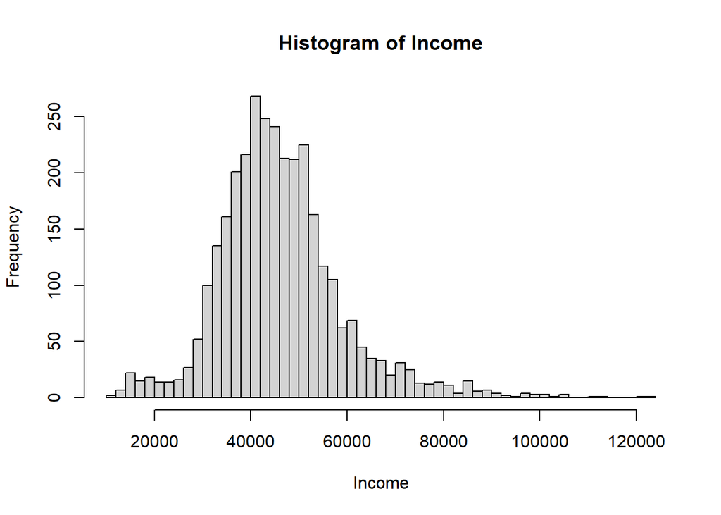

```r
# After reading the data we need now to clean it to prepare for the analysis.
# We started with "income", first we polte it to identify the outlier and then removing it.
# Also , we removed the null values because it make error while do mathematics calculation.
# Then we follow the same steps for the remaining columns that we will gonna use in this phase.
# Currently our desired columns: TotalPop, Income, Poverty, ChildPoverty, Employed, Unemployment, Production, WorkAtHome,PublicWork, SelfEmployed

################################################################################


# First, lets take a look at the histogram for the income to detect the outliers



hist(Adata$Income,
  xlab = "Income",
  main = "Histogram of Income",
  breaks = sqrt(nrow(Adata))
) # set number of bins
```

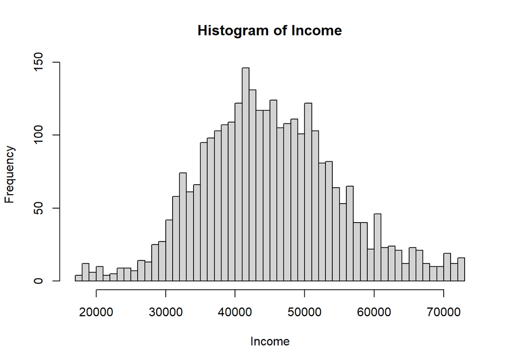

```r
# # Now, we can extract the outliers from the incom using boxplot.stats()$out function.
 income_out <- boxplot.stats(Adata$Income)$out
 income_out


# To count how many outliers in the income
 x <- data.frame(income_out)
x
 nrow(x) # outliers numbers for income


 #Now, we will remove the outliers from our dataset and store the clean result in Adata2

  Adata2<- Adata[-which(Adata$Income %in% income_out),] # here we removed income outlier


 Adata2

 hist(Adata2$Income,
  xlab = "Income",
  main = "Histogram of Income",
  breaks = sqrt(nrow(Adata2))
) # set number of bins
```

```r
# #Adata
# Adata2


 # Now we will remove the naull values from the incmoe to allow for math calculations.

 my.null <- data.frame (subset(Adata2,subset= is.na(Adata2$Income)))# To indicate the null values of income.
my.null


Adata3 <- data.frame (subset(Adata2, subset= CensusId!= 48301 )) # To remove the record that contains null value

# Now we can calculate the max, mean , min .. etc of the income
max(Adata3$Income)
mean(Adata3$Income)
min(Adata3$Income)
```

**Cleaning the data for population column.**

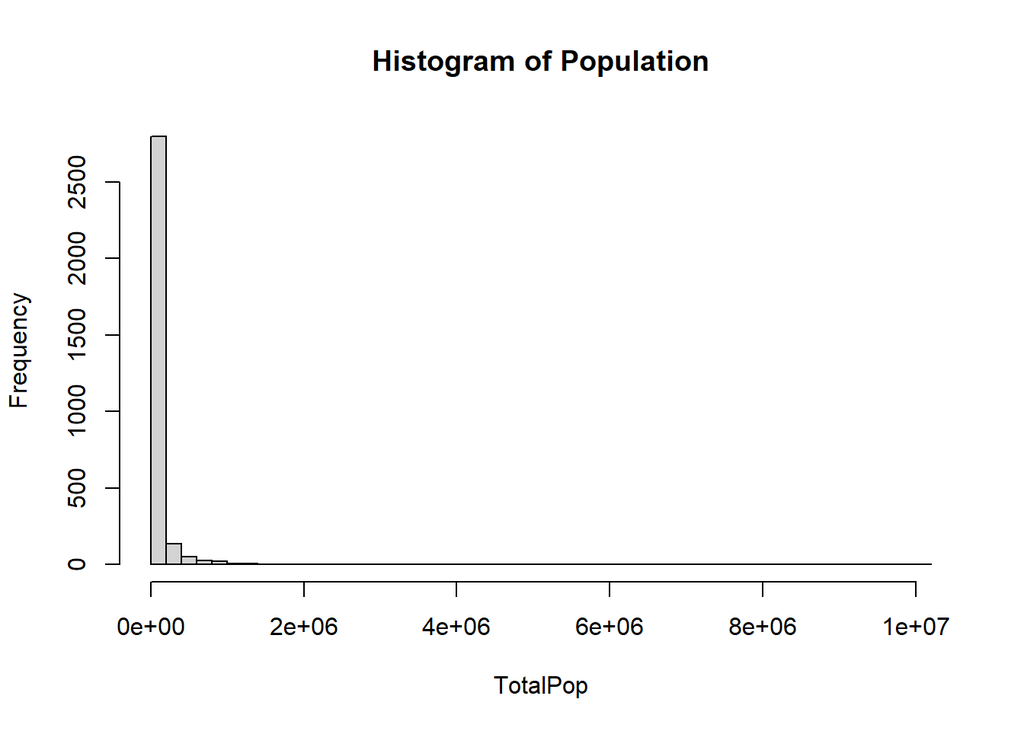

```r
# same thing for population column. clean the data.

# First, lets take a look at the histogram for the population to detect the outliers



hist(Adata3$TotalPop,
  xlab = "TotalPop",
  main = "Histogram of Population",
  breaks = sqrt(nrow(Adata3))
) # set number of bins
```

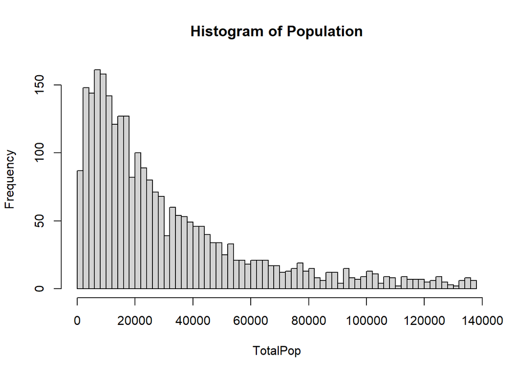

```r
# # Now, we can extract the outliers from the population using boxplot.stats()$out function.
 pop_out <- boxplot.stats(Adata3$TotalPop)$out
 pop_out


# To count how many outliers in the population
 x2 <- data.frame(pop_out)
x2
 nrow(x2) # outliers numbers


 #Now, we will remove the outliers from our dataset and store the clean result in Adata4

  Adata4<- Adata3[-which(Adata3$TotalPop %in% pop_out),] # here we removed  outlier


 Adata4

 hist(Adata4$TotalPop,
  xlab = "TotalPop",
  main = "Histogram of Population",
  breaks = sqrt(nrow(Adata4))
) # set number of bins
```

```r
# #Adata
# Adata2


 # Now we will remove the naull values from the population to allow for math calculations.

 my.null2 <- data.frame (subset(Adata4,subset= is.na(Adata4$TotalPop)))# To indicate the null values of Population
my.null2  # No null values.


# Now we can calculate the max and the mean .. etc of the population.
max(Adata4$TotalPop)
mean(Adata4$TotalPop)
min(Adata4$TotalPop)
```

**Cleaning the data for Poverty column.**

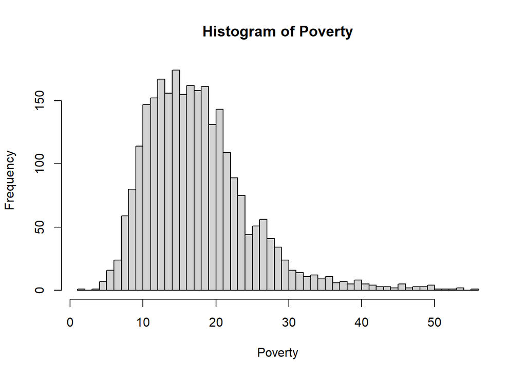

```r
# same thing for poverty column. clean the data.

# First, lets take a look at the histogram for the poverty to detect the outliers



hist(Adata4$Poverty,
  xlab = "Poverty",
  main = "Histogram of Poverty",
  breaks = sqrt(nrow(Adata4))
) # set number of bins
```

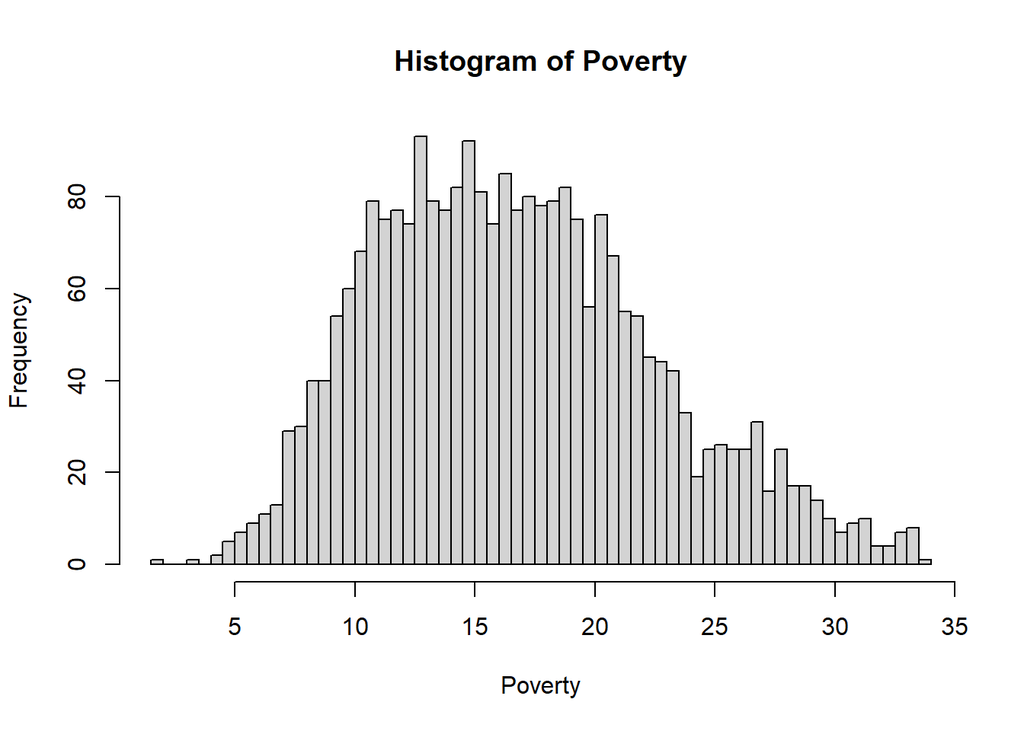

```r
# # Now, we can extract the outliers from the population using boxplot.stats()$out function.
 Poverty_out <- boxplot.stats(Adata4$Poverty)$out
 Poverty_out


# To count how many outliers in the population
 x3 <- data.frame(Poverty_out)
x3
 nrow(x3) # outliers numbers


 #Now, we will remove the outliers from our dataset and store the clean result in Adata5

  Adata5<- Adata4[-which(Adata4$Poverty %in% Poverty_out),] # here we removed  outlier


 Adata5

 hist(Adata5$Poverty,
  xlab = "Poverty",
  main = "Histogram of Poverty",
  breaks = sqrt(nrow(Adata5))
) # set number of bins
```

```r
 # No null values.


# Now we can calculate the max and the mean .. etc of the population.
max(Adata4$Poverty)
mean(Adata4$Poverty)
min (Adata4$Poverty)
```

**Cleaning the data for Child Poverty column.**

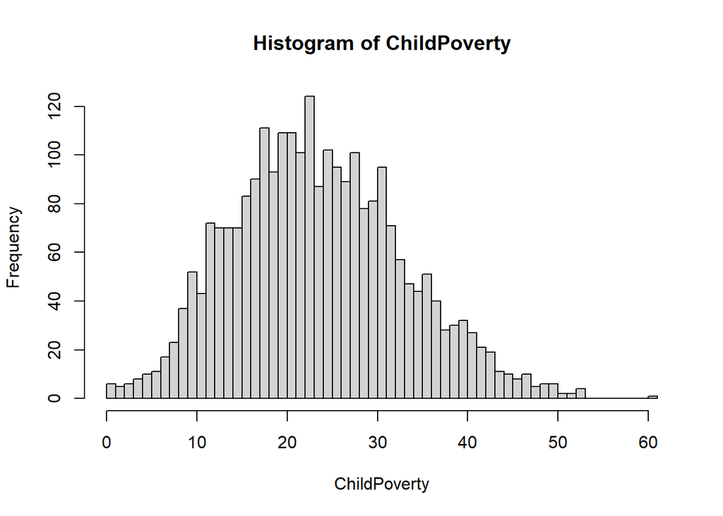

```r
# same thing for Child Poverty column. clean the data.

# First, lets take a look at the histogram for the Child Poverty to detect the outliers



hist(Adata5$ChildPoverty,
  xlab = "ChildPoverty",
  main = "Histogram of ChildPoverty",
  breaks = sqrt(nrow(Adata5))
) # set number of bins
```

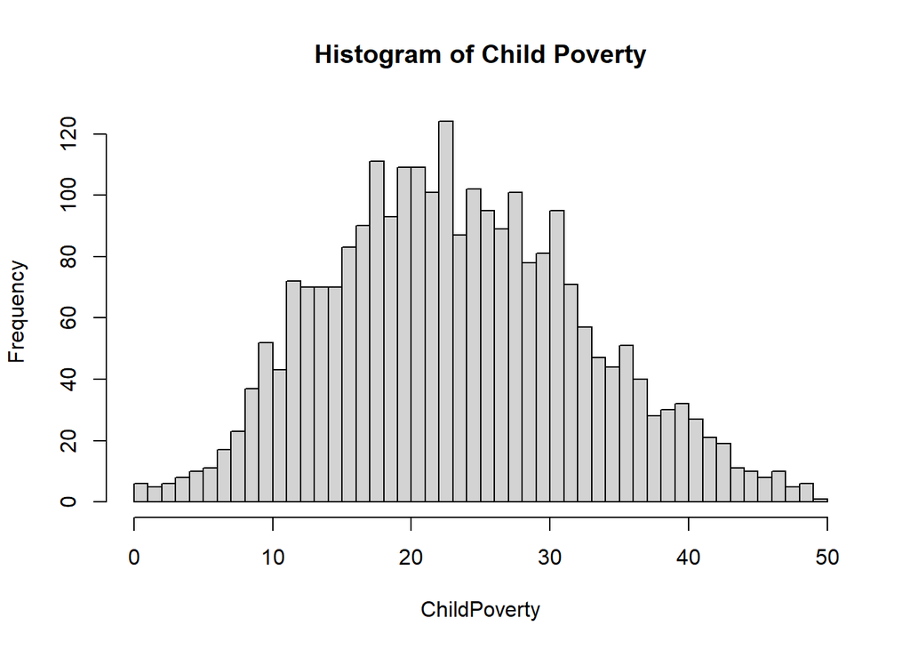

```r
# # Now, we can extract the outliers using boxplot.stats()$out function.
 ChildPoverty_out <- boxplot.stats(Adata5$ChildPoverty)$out
 ChildPoverty_out


# To count how many outliers in the population
 x4 <- data.frame(ChildPoverty_out)
x4
 nrow(x4) # outliers numbers


 #Now, we will remove the outliers from our dataset and store the clean result in Adata6

  Adata6<- Adata5[-which(Adata5$ChildPoverty %in% ChildPoverty_out),] # here we removed  outlier


 Adata6

 hist(Adata6$ChildPoverty,
  xlab = "ChildPoverty",
  main = "Histogram of Child Poverty",
  breaks = sqrt(nrow(Adata6))
) # set number of bins
```

```r
 my.null3 <- data.frame (subset(Adata6,subset= is.na(Adata6$ChildPoverty)))# To indicate the null values
my.null3


 Adata7 <- data.frame (subset(Adata6, subset= CensusId!= 15005 )) # To remove the record that contains null value



# Now we can calculate the max and the mean .. etc of the population.
max(Adata7$ChildPoverty)
mean(Adata7$ChildPoverty)
min (Adata7$ChildPoverty)
```

**Cleaning the data for Employed column**

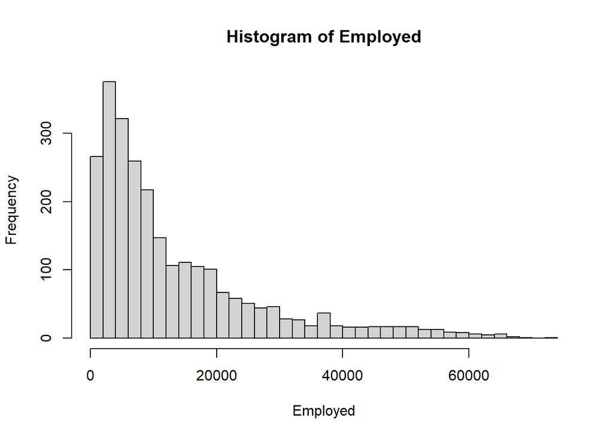

```r
# same thing for Employed column. clean the data.

# First, lets take a look at the histogram for the Employed to detect the outliers



hist(Adata7$Employed,
  xlab = "Employed",
  main = "Histogram of Employed",
  breaks = sqrt(nrow(Adata7))
) # set number of bins
```

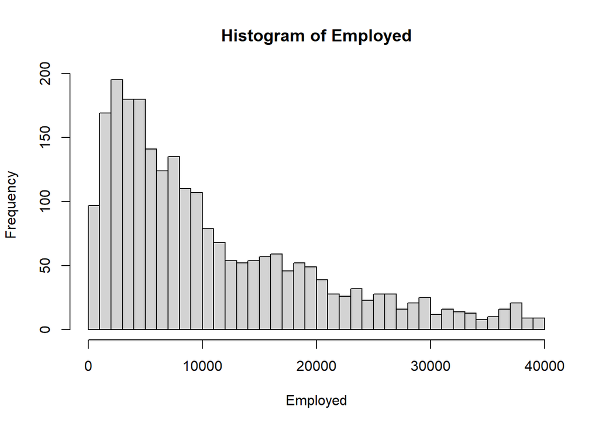

```r
# # Now, we can extract the outliers using boxplot.stats()$out function.
 Employed_out <- boxplot.stats(Adata7$Employed)$out
 Employed_out


# To count how many outliers in the population
 x5 <- data.frame(Employed_out)
x5
 nrow(x5) # outliers numbers


 #Now, we will remove the outliers from our dataset and store the clean result in Adata8

  Adata8<- Adata7[-which(Adata7$Employed %in% Employed_out),] # here we removed outlier


 Adata8

 hist(Adata8$Employed,
  xlab = "Employed",
  main = "Histogram of Employed",
  breaks = sqrt(nrow(Adata8))
) # set number of bins
```

```r
# No null values.


# # Now we can calculate the max and the mean .. etc of the population.
max(Adata8$Employed)
mean(Adata8$Employed)
min (Adata8$Employed)
```

**Cleaning the data for Unemployment column**

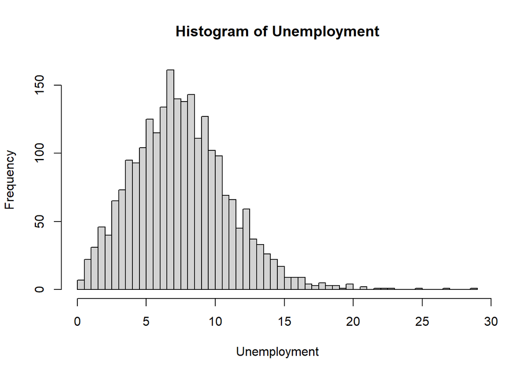

```r
# same thing for Unemployment column. clean the data.

# First, lets take a look at the histogram for the Unemployment to detect the outliers



hist(Adata8$Unemployment,
  xlab = "Unemployment",
  main = "Histogram of Unemployment",
  breaks = sqrt(nrow(Adata8))
) # set number of bins
```

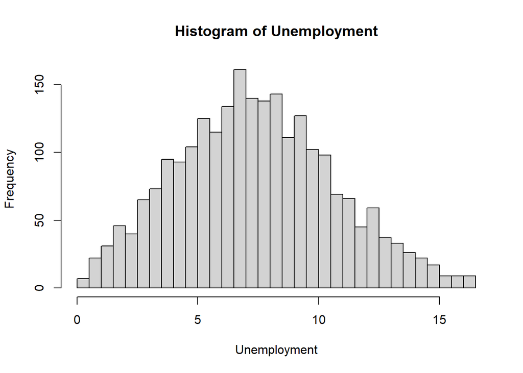

```r
 # Now, we can extract the outliers using boxplot.stats()$out function.
 Unemployment_out <- boxplot.stats(Adata8$Unemployment)$out
 Unemployment_out
#
#
#  To count how many outliers in the population
  x6 <- data.frame(Unemployment_out)
 x6
  nrow(x6) # outliers numbers
#
#
 #Now, we will remove the outliers from our dataset and store the clean result in Adata9
#
   Adata10<- Adata8[-which(Adata8$Unemploymen %in% Unemployment_out),] # here we removed outlier
#
#
 Adata10
#
  hist(Adata10$Unemployment,
   xlab = "Unemployment",
   main = "Histogram of Unemployment",
   breaks = sqrt(nrow(Adata10))
) # set number of bins
```

```r
# # No null values.

#
# # # Now we can calculate the max and the mean .. etc .
 max(Adata10$Unemployment)
 mean(Adata10$Unemployment)
min (Adata10$Unemployment)
```

**Cleaning the data for Production column**

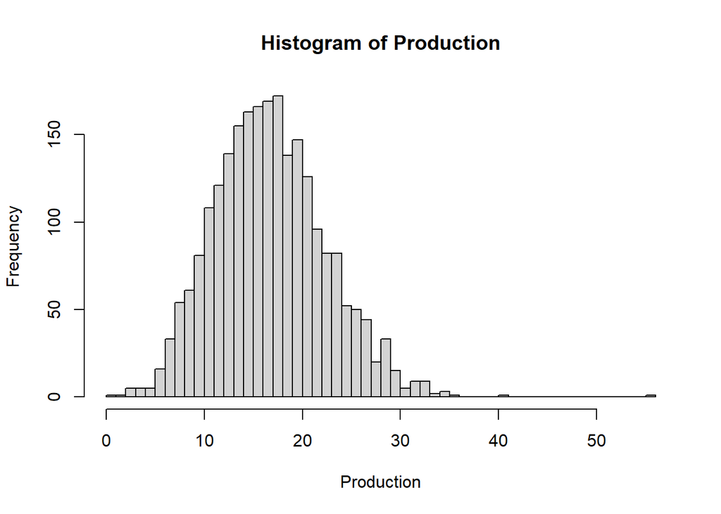

```r
# same thing for Production column. clean the data.

# First, lets take a look at the histogram for the Production to detect the outliers



hist(Adata10$Production,
  xlab = "Production",
  main = "Histogram of Production",
  breaks = sqrt(nrow(Adata10))
) # set number of bins
```

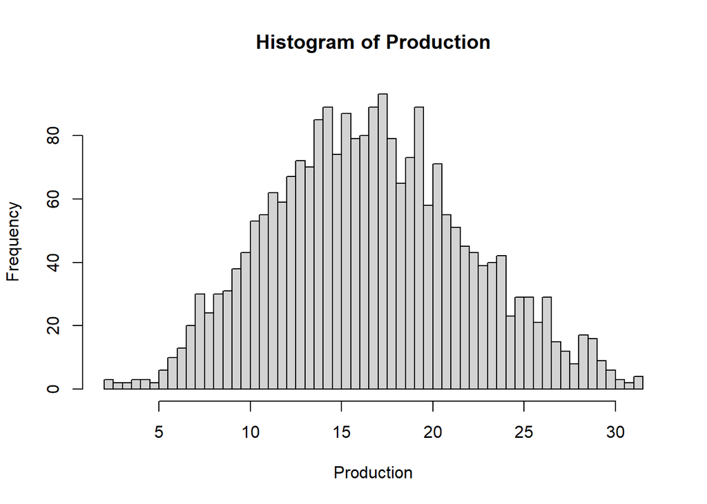

```r
 # Now, we can extract the outliers using boxplot.stats()$out function.
 production_out <- boxplot.stats(Adata10$Production)$out
 production_out
#
#
#  To count how many outliers in the population
  x7 <- data.frame(production_out)
 x7
  nrow(x7) # outliers numbers
#
#
 #Now, we will remove the outliers from our dataset and store the clean result in Adata11
#
   Adata11<- Adata10[-which(Adata10$Production %in% production_out),] # here we removed outlier
#
#
 Adata11
#
  hist(Adata11$Production,
   xlab = "Production",
   main = "Histogram of Production",
   breaks = sqrt(nrow(Adata11))
) # set number of bins
```

```r
# # No null values.

#
# # # Now we can calculate the max and the mean .. etc .
 max(Adata11$Production)
 mean(Adata11$Production)
min (Adata11$Production)
```

**Cleaning the data for WorkAtHome column**

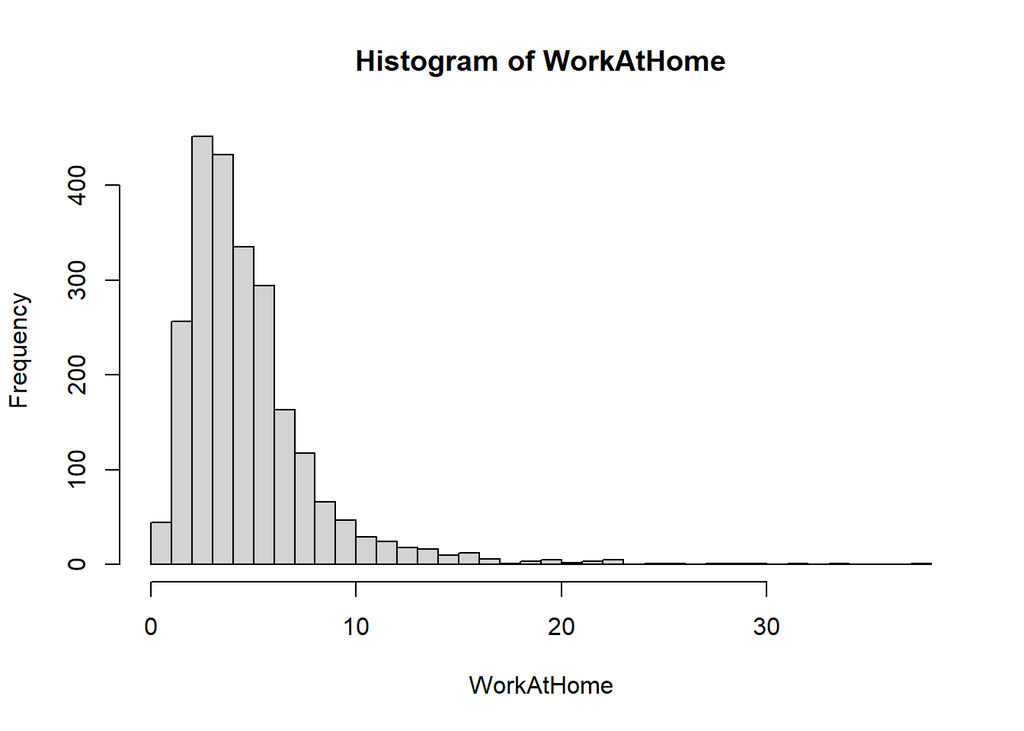

```r
# same thing for WorkAtHome column. clean the data.

# First, lets take a look at the histogram for the WorkAtHome to detect the outliers



hist(Adata11$WorkAtHome,
  xlab = "WorkAtHome",
  main = "Histogram of WorkAtHome",
  breaks = sqrt(nrow(Adata11))
) # set number of bins
```

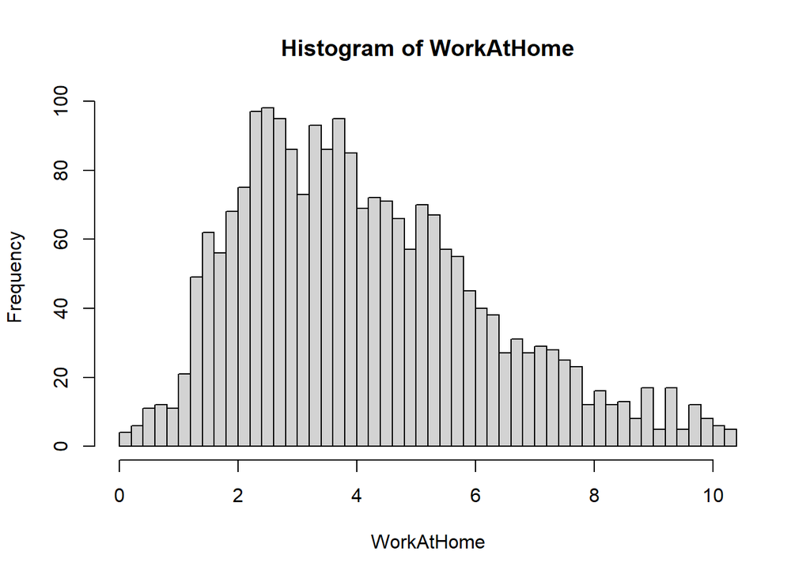

```r
 # Now, we can extract the outliers using boxplot.stats()$out function.
 WorkAtHome_out <- boxplot.stats(Adata11$WorkAtHome)$out
 WorkAtHome_out
#
#
#  To count how many outliers in the population
  x8 <- data.frame(WorkAtHome_out)
 x8
  nrow(x8) # outliers numbers
#
#
 #Now, we will remove the outliers from our dataset and store the clean result in Adata11
#
   Adata12<- Adata11[-which(Adata11$WorkAtHome %in% WorkAtHome_out),] # here we removed outlier
#
#
 Adata12
#
  hist(Adata12$WorkAtHome,
   xlab = "WorkAtHome",
   main = "Histogram of WorkAtHome",
   breaks = sqrt(nrow(Adata12))
) # set number of bins
```

```r
# # No null values.

#
# # # Now we can calculate the max and the mean .. etc .
 max(Adata12$WorkAtHome)
 mean(Adata12$WorkAtHome)
min (Adata12$WorkAtHome)
```

**Cleaning the data for PublicWork column**

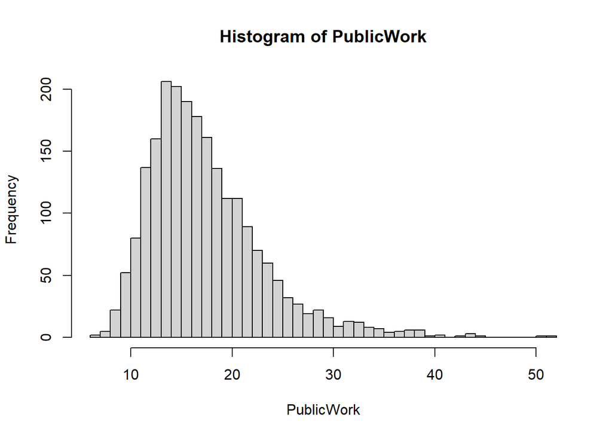

```r
# same thing for PublicWork column. clean the data.

# First, lets take a look at the histogram for the PublicWork to detect the outliers



hist(Adata12$PublicWork,
  xlab = "PublicWork",
  main = "Histogram of PublicWork",
  breaks = sqrt(nrow(Adata12))
) # set number of bins
```

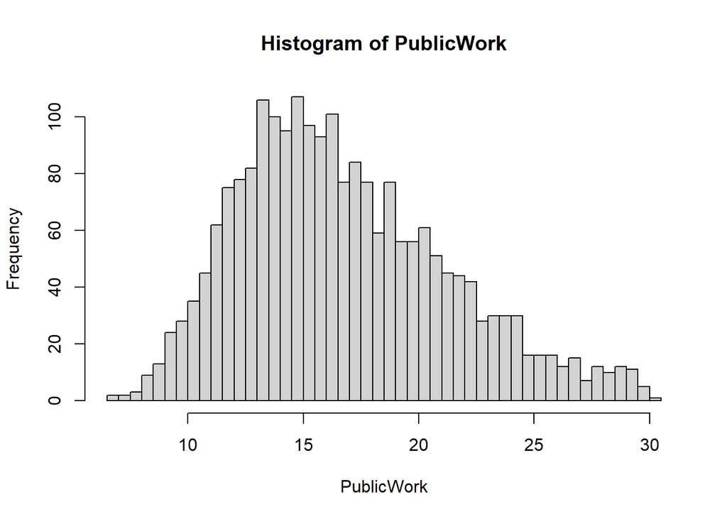

```r
 # Now, we can extract the outliers using boxplot.stats()$out function.
 PublicWork_out <- boxplot.stats(Adata12$PublicWork)$out
 PublicWork_out
#
#
#  To count how many outliers in the population
  x9 <- data.frame(PublicWork_out)
 x9
  nrow(x9) # outliers numbers
#
#
 #Now, we will remove the outliers from our dataset and store the clean result in Adata11
#
   Adata13<- Adata12[-which(Adata12$PublicWork %in% PublicWork_out),] # here we removed outlier
#
#
 Adata13
#
  hist(Adata13$PublicWork,
   xlab = "PublicWork",
   main = "Histogram of PublicWork",
   breaks = sqrt(nrow(Adata13))
) # set number of bins
```

```r
# # No null values.

#
# # # Now we can calculate the max and the mean .. etc .
 max(Adata13$PublicWork)
 mean(Adata13$PublicWork)
min (Adata13$PublicWork)
```

[output not shown]

**Cleaning the data for SelfEmployed column**

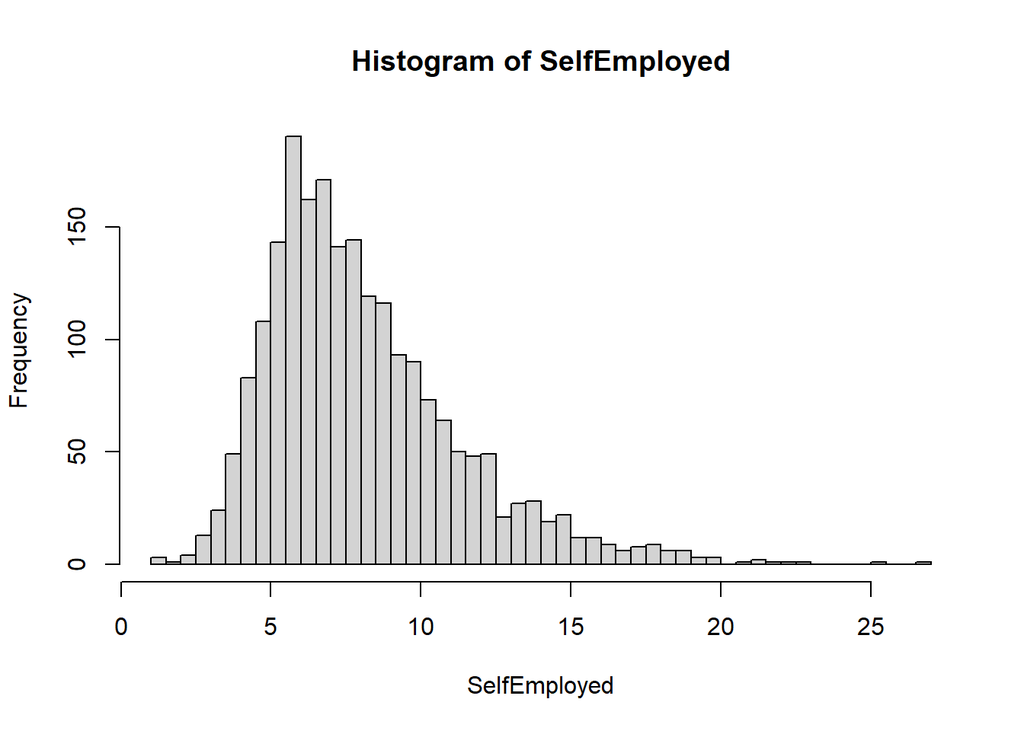

```r
# same thing for PublicWork column. clean the data.

# First, lets take a look at the histogram for the PublicWork to detect the outliers



hist(Adata13$SelfEmployed,
  xlab = "SelfEmployed",
  main = "Histogram of SelfEmployed",
  breaks = sqrt(nrow(Adata13))
) # set number of bins
```

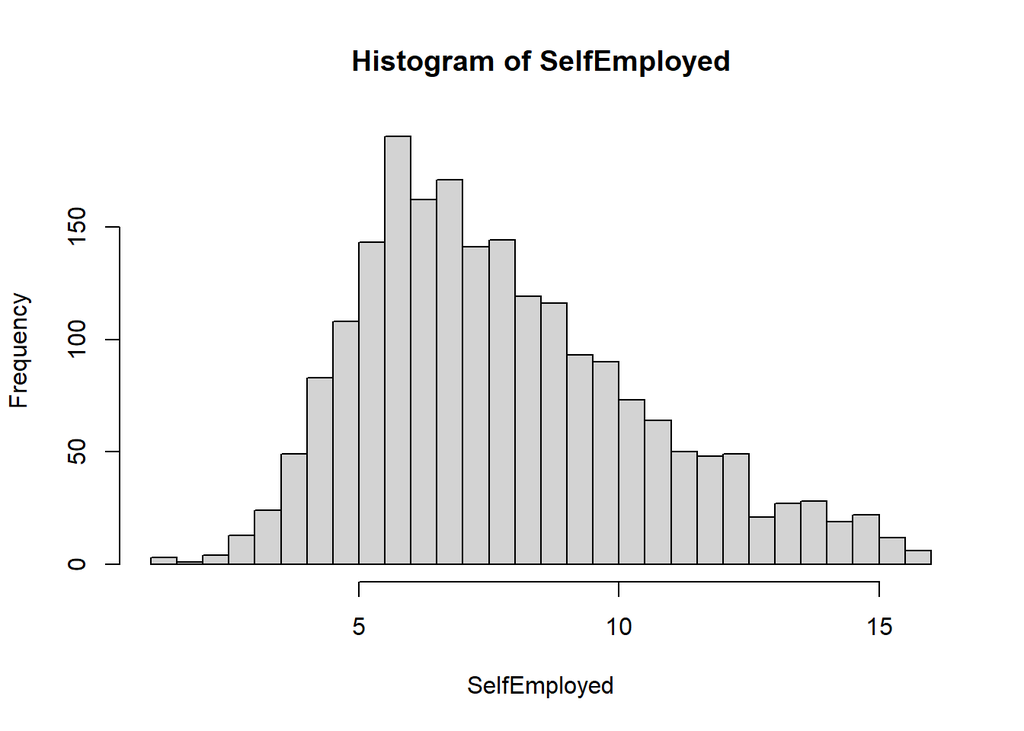

```r
 # Now, we can extract the outliers using boxplot.stats()$out function.
 SelfEmployed_out <- boxplot.stats(Adata13$SelfEmployed)$out
 SelfEmployed_out
#
#
#  To count how many outliers in the population
  x10 <- data.frame(SelfEmployed_out)
 x10
  nrow(x10) # outliers numbers
#
#
 #Now, we will remove the outliers from our dataset and store the clean result in Adata11
#
   Adata14<- Adata13[-which(Adata13$SelfEmployed %in% SelfEmployed_out),] # here we removed outlier
#
#
 Adata14
#
  hist(Adata14$SelfEmployed,
   xlab = "SelfEmployed",
   main = "Histogram of SelfEmployed",
   breaks = sqrt(nrow(Adata14))
) # set number of bins
```

```r
# # No null values.

#
# # # Now we can calculate the max and the mean .. etc .
 max(Adata14$SelfEmployed)
 mean(Adata14$SelfEmployed)
min (Adata14$SelfEmployed)
```

[output not shown]

**Final dataset**

As we can see bellow, after performing the cleansing process, we removed 1,147 record which include 2 NA values and 1,145 outliers. Now we have 2073 obs across 22 variables, the data shrink, however we have now more accurate dataset that will help us perform reliable tests as well as more accurate results.

```r
# This is the final data set:
Adata9 = Adata14

str(Adata9)

#summary(Adata9)

#########################
```

```
## 'data.frame':    2073 obs. of  22 variables:
##  $ CensusId    : int  1001 1007 1009 1013 1017 1019 1021 1023 1027 1029 ...
##  $ State       : chr  "Alabama" "Alabama" "Alabama" "Alabama" ...
##  $ County      : chr  "Autauga" "Bibb" "Blount" "Butler" ...
##  $ TotalPop    : int  55221 22604 57710 20354 34079 26008 43819 13395 13537 15002 ...
##  $ Men         : int  26745 12073 28512 9502 16258 12975 21619 6382 6671 7334 ...
##  $ Women       : int  28476 10531 29198 10852 17821 13033 22200 7013 6866 7668 ...
##  $ Citizen     : int  40725 17495 42345 15581 26462 20600 31728 10568 10312 11367 ...
##  $ Income      : num  51281 38678 45813 32229 34177 ...
##  $ Poverty     : num  12.9 16.8 16.7 25.4 21.6 19.2 19.1 23.4 16.7 17 ...
##  $ ChildPoverty: num  18.6 27.9 27.2 39.2 37.2 30.1 30.6 34.4 22.5 26.3 ...
##  $ Professional: num  33.2 21.5 28.5 27.5 23.3 29.3 27.2 24.9 21.5 28.9 ...
##  $ Service     : num  17 17.9 14.1 16.6 14.5 16 14.3 15.4 13.3 11.7 ...
##  $ Office      : num  24.2 17.8 23.9 21.9 26.3 19.5 23.7 19.6 20.8 23.1 ...
##  $ Construction: num  8.6 19 13.5 10.3 11.5 13.7 15.3 18.3 15.3 15.6 ...
##  $ Production  : num  17.1 23.7 19.9 23.7 24.4 21.5 19.5 21.8 29.1 20.7 ...
##  $ WorkAtHome  : num  1.8 0.7 2.3 1.7 2.1 2.5 1.9 0.8 2.1 3.4 ...
##  $ Employed    : int  23986 8294 22189 7813 13689 10155 17895 4405 5180 6065 ...
##  $ PrivateWork : num  73.6 76.8 82 77.4 85.1 73.1 80.3 77.5 77.5 76.3 ...
##  $ PublicWork  : num  20.9 16.1 13.5 16.2 12.1 18.5 15.2 16.8 14.7 15.3 ...
##  $ SelfEmployed: num  5.5 6.7 4.2 6.2 2.8 7.9 4.1 5.4 7.8 8.4 ...
##  $ FamilyWork  : num  0 0.4 0.4 0.2 0 0.5 0.5 0.3 0 0 ...
##  $ Unemployment: num  7.6 8.3 7.7 10.9 8.9 7.9 9.1 13.6 9.4 8.3 ...
```

**Final Dataset Summary**

```r
summary(Adata9)
```

```
##     CensusId        State              County             TotalPop
##  Min.   : 1001   Length:2073        Length:2073        Min.   :   267
##  1st Qu.:19083   Class :character   Class :character   1st Qu.: 11206
##  Median :29111   Mode  :character   Mode  :character   Median : 21355
##  Mean   :30918                                         Mean   : 27741
##  3rd Qu.:47003                                         3rd Qu.: 39304
##  Max.   :72139                                         Max.   :108501
##       Men            Women          Citizen          Income         Poverty
##  Min.   :  136   Min.   :  131   Min.   :  199   Min.   :22698   Min.   : 3.4
##  1st Qu.: 5626   1st Qu.: 5578   1st Qu.: 8452   1st Qu.:37759   1st Qu.:12.7
##  Median :10705   Median :10682   Median :16012   Median :43355   Median :16.6
##  Mean   :13822   Mean   :13919   Mean   :20863   Mean   :44253   Mean   :16.9
##  3rd Qu.:19623   3rd Qu.:19736   3rd Qu.:29424   3rd Qu.:50115   3rd Qu.:20.6
##  Max.   :55190   Max.   :54262   Max.   :97679   Max.   :72890   Max.   :33.5
##   ChildPoverty   Professional     Service         Office      Construction
##  Min.   : 0.0   Min.   :13.5   Min.   : 5.0   Min.   : 7.1   Min.   : 1.7
##  1st Qu.:17.3   1st Qu.:25.9   1st Qu.:16.1   1st Qu.:20.1   1st Qu.:11.0
##  Median :23.2   Median :28.6   Median :18.1   Median :22.0   Median :12.9
##  Mean   :23.9   Mean   :29.0   Mean   :18.3   Mean   :21.9   Mean   :13.5
##  3rd Qu.:30.1   3rd Qu.:31.7   3rd Qu.:20.2   3rd Qu.:23.7   3rd Qu.:15.3
##  Max.   :49.2   Max.   :51.3   Max.   :36.6   Max.   :35.4   Max.   :39.2
##    Production     WorkAtHome      Employed      PrivateWork     PublicWork
##  Min.   : 2.4   Min.   : 0.0   Min.   :  166   Min.   :55.3   Min.   : 6.9
##  1st Qu.:13.7   1st Qu.: 2.6   1st Qu.: 4648   1st Qu.:71.9   1st Qu.:13.4
##  Median :17.1   Median : 3.8   Median : 8898   Median :75.7   Median :16.1
##  Mean   :17.3   Mean   : 4.1   Mean   :11820   Mean   :75.1   Mean   :16.8
##  3rd Qu.:20.7   3rd Qu.: 5.3   3rd Qu.:16962   3rd Qu.:79.1   3rd Qu.:19.7
##  Max.   :31.4   Max.   :10.4   Max.   :39915   Max.   :88.3   Max.   :30.2
##   SelfEmployed     FamilyWork    Unemployment
##  Min.   : 1.30   Min.   :0.00   Min.   : 0.50
##  1st Qu.: 5.80   1st Qu.:0.10   1st Qu.: 5.50
##  Median : 7.30   Median :0.20   Median : 7.50
##  Mean   : 7.82   Mean   :0.28   Mean   : 7.68
##  3rd Qu.: 9.50   3rd Qu.:0.40   3rd Qu.: 9.60
##  Max.   :15.60   Max.   :4.00   Max.   :16.40
```

**Standard deviation for the columns to check how the data spread out after cleansing process**

```r
# Standard deviation for the columns:

sd(Adata9$Income)
sd(Adata9$TotalPop)
sd(Adata9$Poverty)
sd(Adata9$ChildPoverty)
sd(Adata9$Employed)
sd(Adata9$Unemployment)
sd(Adata9$Production)
sd(Adata9$WorkAtHome)
sd(Adata9$PublicWork)
sd(Adata9$SelfEmployed)
```

```
## [1] 8727
## [1] 21184
## [1] 5.58
## [1] 9
## [1] 9227
## [1] 3.03
## [1] 5.13
## [1] 1.97
## [1] 4.53
## [1] 2.73
```

**Normality tests**

**Section 3.2: Normality tests**

**The following graphs are the normality test for our desired columns.**

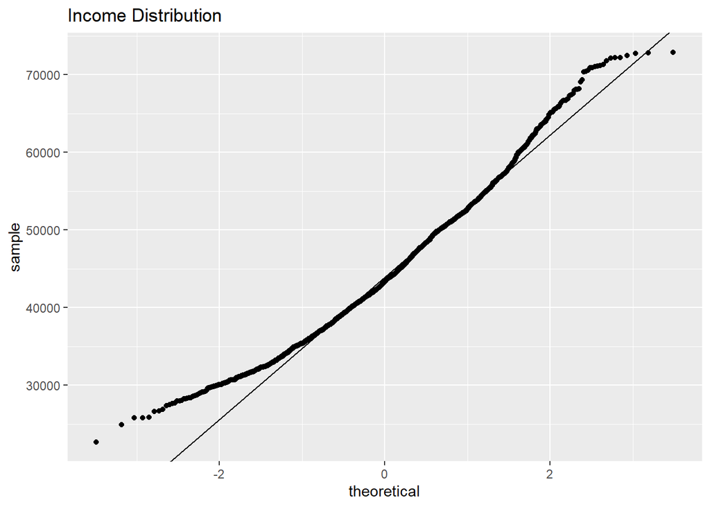

```r
library(ggplot2)



#This code enable us to use qqplot.data function (to draw a line)

qqplot.data <- function (vec) # argument: vector of numbers
{
  y <- quantile(vec[!is.na(vec)], c(0.25, 0.75))
  x <- qnorm(c(0.25, 0.75))
  slope <- diff(y)/diff(x)
  int <- y[1L] - slope * x[1L]
  d <- data.frame(resids = vec)
  ggplot(d, aes(sample = resids)) + stat_qq() + geom_abline(slope = slope, intercept = int)

}

# Histogram that use ggplot:

# 1 Graph for income distribution:
g1 <- qqplot.data(Adata9$Income)+labs(title = "Income Distribution")
g1
```

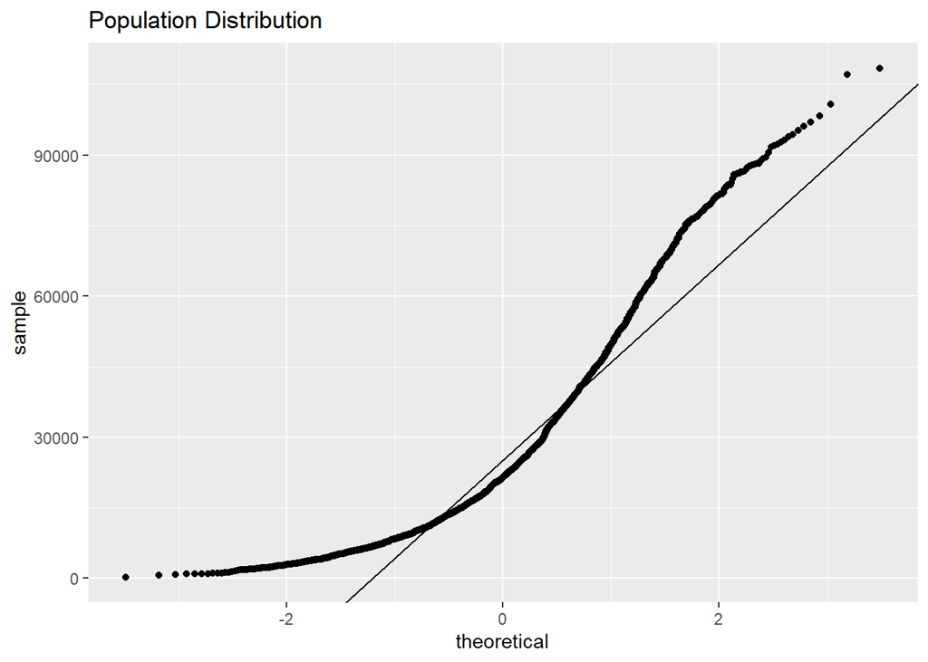

```r
# 2 Graph for population distribution
g2 <- qqplot.data(Adata9$TotalPop)+labs(title = "Population Distribution")
g2
```

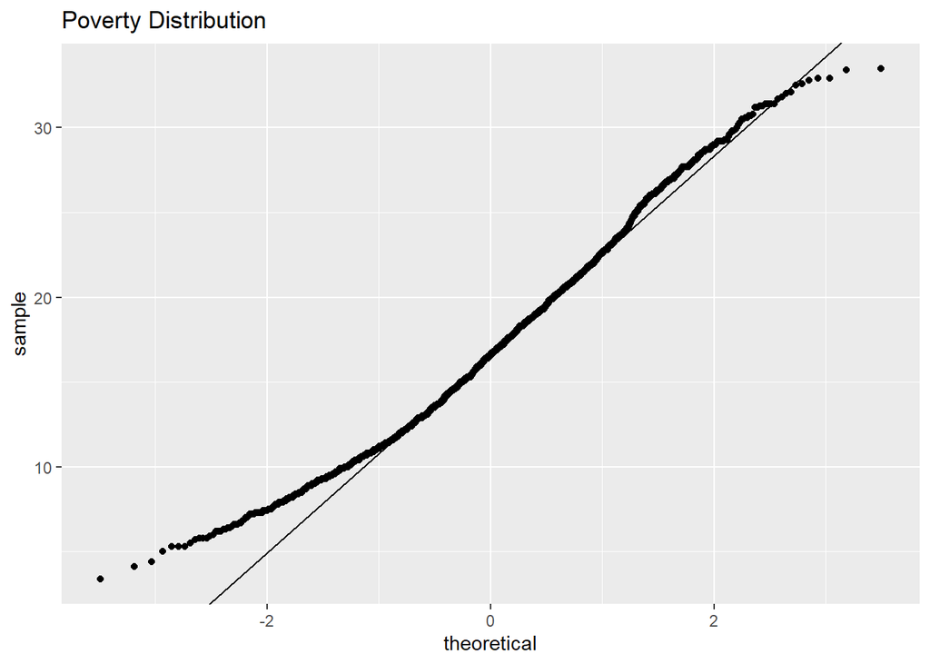

```r
# 3 Graph for Poverty distribution
g3 <- qqplot.data(Adata9$Poverty)+labs(title = "Poverty Distribution")
g3
```

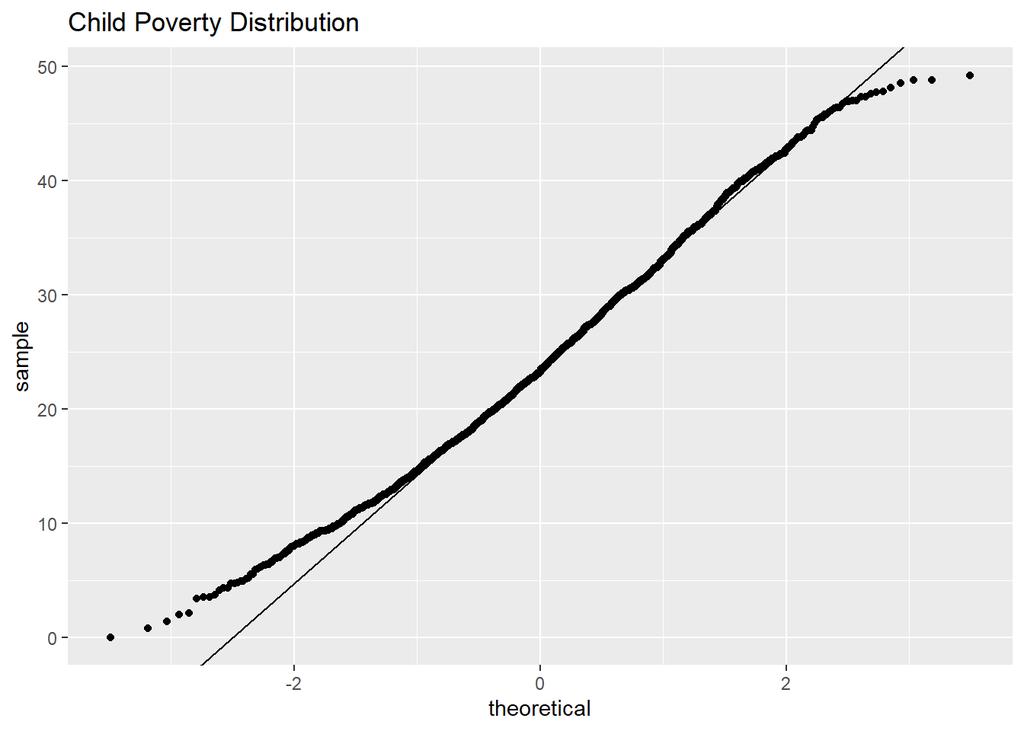

```r
# 4 Graph for child poverty distribution
g4 <- qqplot.data(Adata9$ChildPoverty)+labs(title = "Child Poverty Distribution")
g4
```

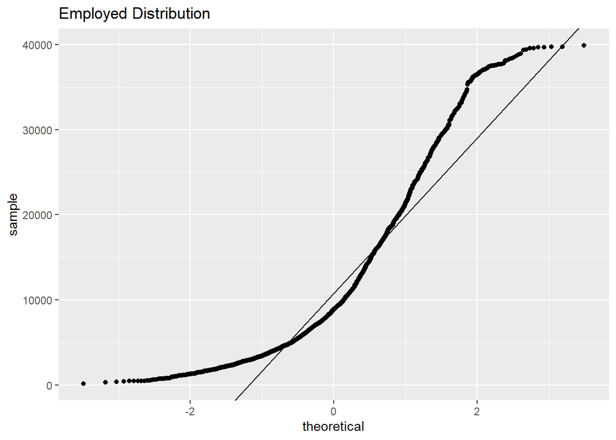

```r
# 5 Graph for Employed distribution
g5 <- qqplot.data(Adata9$Employed)+labs(title = "Employed Distribution")
g5
```

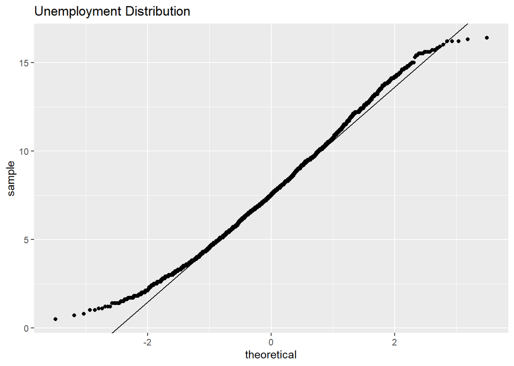

```r
# 6 Graph for unemployment distribution
g6 <- qqplot.data(Adata9$Unemployment)+labs(title = "Unemployment Distribution")
g6
```

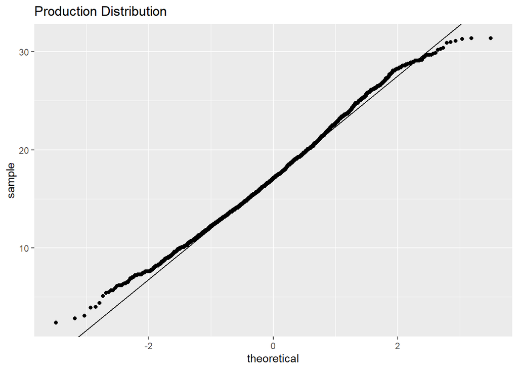

```r
# 7 Graph for Production distribution
g7 <- qqplot.data(Adata9$Production)+labs(title = "Production Distribution")
g7
```

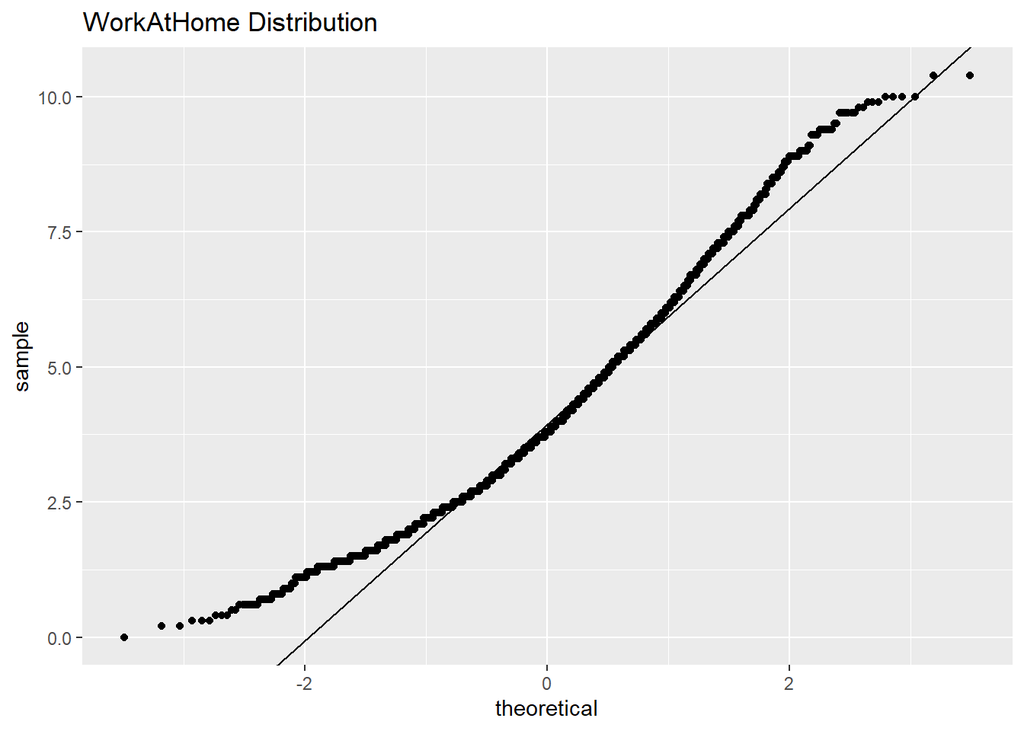

```r
# 8 Graph for Production distribution
g8 <- qqplot.data(Adata9$WorkAtHome)+labs(title = "WorkAtHome Distribution")
g8
```

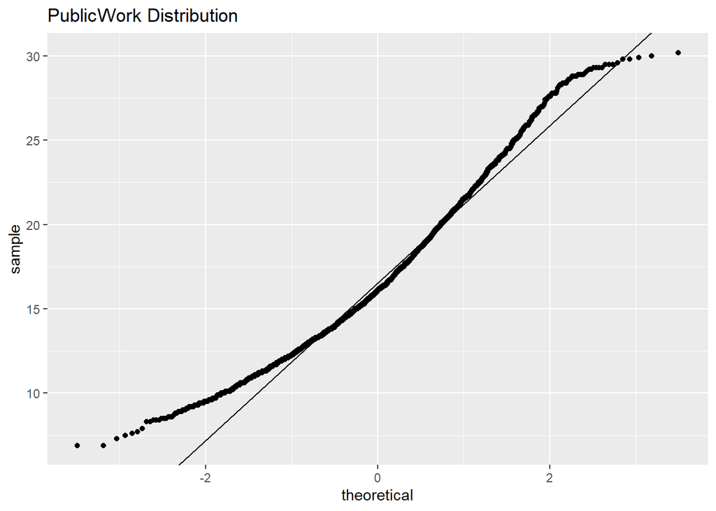

```r
# 9 Graph for PublicWork distribution
g9 <- qqplot.data(Adata9$PublicWork)+labs(title = "PublicWork Distribution")
g9
```

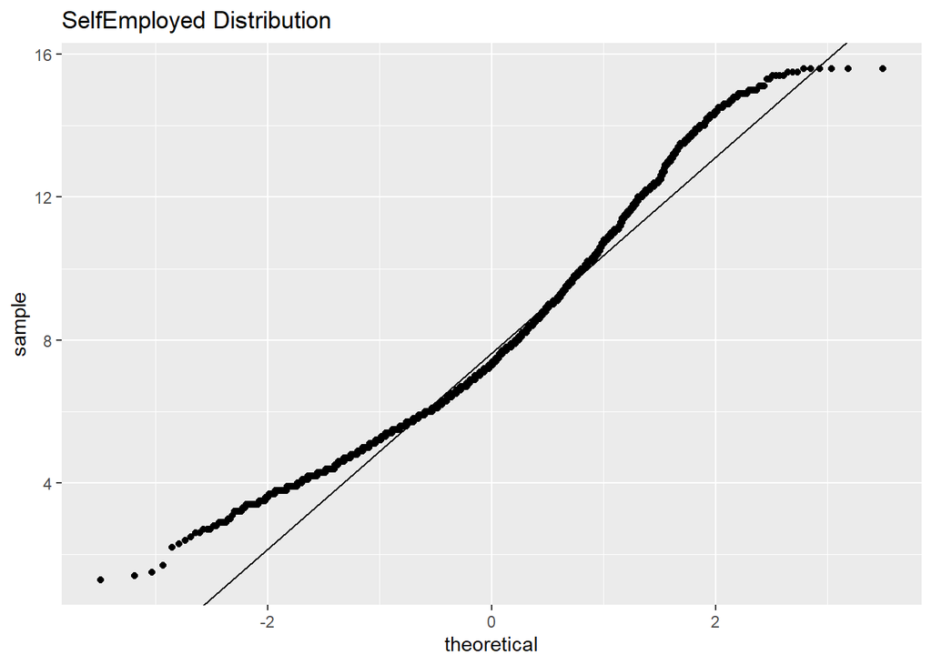

```r
# 10 Graph for SelfEmployed distribution
g10 <- qqplot.data(Adata9$SelfEmployed)+labs(title = "SelfEmployed Distribution")
g10
```

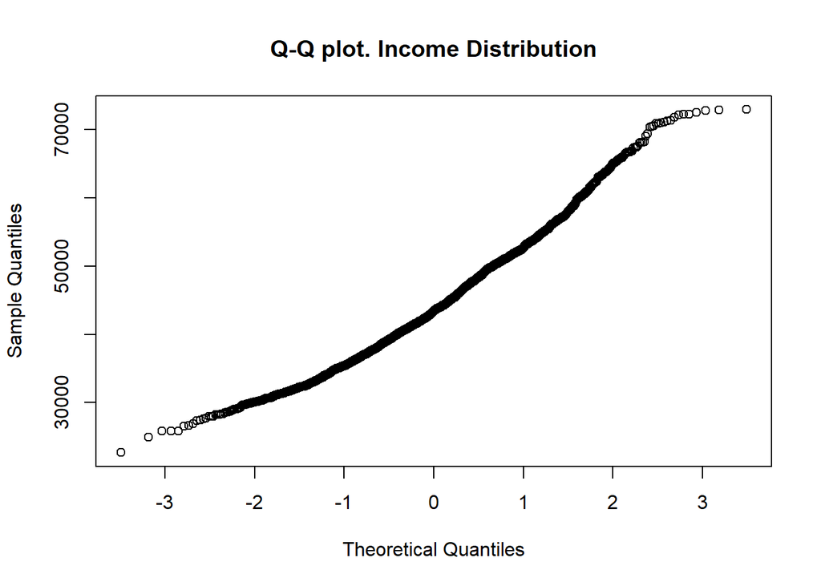

```r
###########################################



# Additional graphs for two variables only.  QQ-plot that use qqnorm

# 1 Graph for income
qqnorm(Adata9$Income,main = "Q-Q plot. Income Distribution")
```

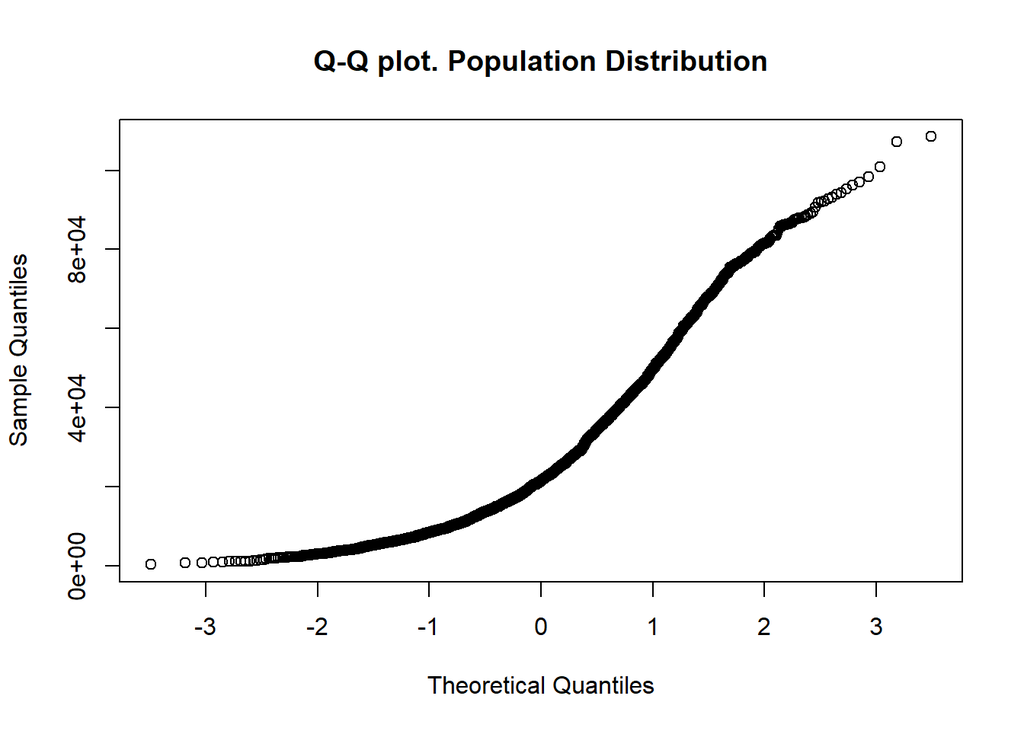

```r
#2 Graph for population
 qqnorm(Adata9$TotalPop,main = "Q-Q plot. Population Distribution")
```